Marc Rexheuser  
Frachtmanagement + Datenanalyse  
0049.157.54090160 Email [LinkedIn](https://www.linkedin.com/in/marc-rexheuser/) en

# Kundensegmentierung deluxe

ABC-Analyse war vorgestern. Sie segmentiert nur nach *einem* Parameter, meist Umsatz oder *einer* anderen Finanzgröße. Die Kundenwertanalyse segmentiert Kunden nach *Aktualität*, *Frequenz* und der *monetären Bedeutung* von Aufträgen. So lassen sich Vertriebsmaßnahmen passend zu den Kundenprofilen ableiten. So wird sichergesellt, dass das Vertriebsbudget effektiv eingesetzt wird. Gleichzeitig profitieren Kunden von Maßnahmen und Informationen, die wirklich relevant sind. Kurz gesagt, hier ist der Griff am Kundenstamm. So können mögliche Abhängigkeiten von bestimmten Kunden erkannt und Risiken besser eingeschätzt werden.

Das *klassisch - analoge* RFM Scoring Modell ist anfällig für hohe Subjektivität bei der manuellen Vergabe von Scoring Punkten für die drei Parameter. Auch ist die Aussagekraft limitiert. Auf der anderen Seite ist die Segmentierung mittels *Clustering Algorithmen* sehr exakt und sorgt für Objektivität. Die Anwendung und die Kommunikation der Ergebnisse gestaltet sich aber schwieriger.

**R**=Recency (Aktualität), **F**=Frequency (Frequenz), **M**=Monetary Impact (monetäre Bedeutung)

Nachfolgend wird das beste dieser zwei Welten miteinander verbunden - die einfach nachvollziehbare RFM Methode aus dem Marketing mit einem komplexen Clustering Algorithmus aus dem Data Mining.

## Welche Daten?

Die Aktualität, in Bezug auf jeden einzelnen Kunden, wird mit der Kalenderwoche des jüngsten Auftrages erfasst. Je höher also der Wert, umso höher oder besser die Aktualität. Die Frequenz wird durch die Anzahl aller Aufträge eines jeden Kunden dargestellt. Je höher der Wert, umso besser. Die monetäre Bedeutung wird durch die Summe aller Umsätze eines jeden Kunden ausgedrückt. Je höher der Wert…

## Transformieren der Daten

Um vergleichbare Kundensegmente herauszuarbeiten wurden die Daten zunächst skaliert. Weiterhin musste eine extreme Schiefe korrigiert werden. Die Transformation nach Johnson brachte hier die besten Ergebnisse, um annähernd Normalverteilung zu erreichen.

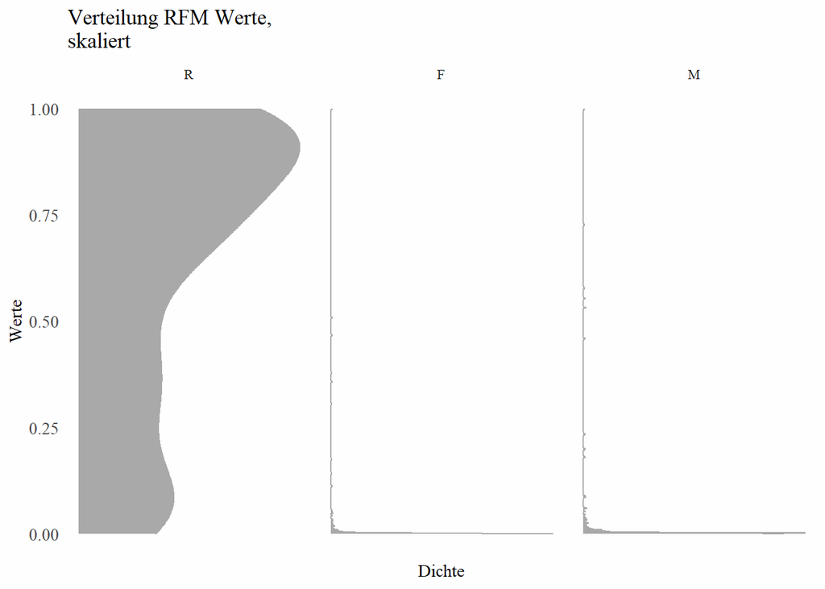

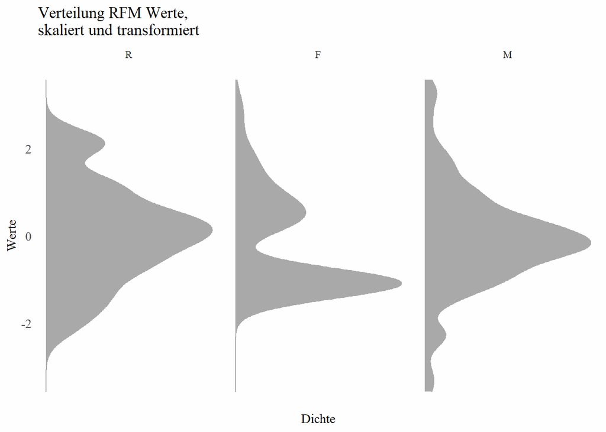

## Clustering

Die Cluster Analyse ergab eine optimale Clusteranzahl von 8. Die nachfolgende Tabelle zeigt die einzelnen Cluster mit Ihren Werten für ein *RFM-Profil* sowie den Anteil des jeweiligen Clusters am Gesamtkundenstamm.

Cluster Nummer 1 fällt sofort auf, mit seinem extrem hohen Wert für die monetäre Bedeutung (M). Ebenso sind die Werte für R und F auffällig hoch. Dies deutet auf ein Kundencluster hin, welches aus Unternehmenssicht unverzichtbar ist. Vor allem, weil die Kunden dieses Clusters zusammen nur 4 % der Kundenanzahl ausmachen.

| Cluster | Anteil | R | F | M |
| --- | --- | --- | --- | --- |
| 1 | 0.04 | 1.87 | 2.79 | 3.10 |
| 2 | 0.07 | 1.91 | -0.11 | -0.27 |
| 3 | 0.13 | 0.97 | 1.38 | 1.36 |
| 4 | 0.22 | -0.30 | 0.56 | 0.40 |
| 5 | 0.12 | -1.70 | -1.05 | -0.66 |
| 6 | 0.21 | 0.50 | -1.09 | -0.55 |
| 7 | 0.15 | -0.45 | -1.09 | -0.43 |
| 8 | 0.06 | -0.32 | -1.09 | -2.68 |

## Visualisierung

Die Grafik *RFM Clustering Kundenstamm* zeigt die einzelnen RFM-Profile der errechneten Cluster - als Linie über alle drei Parameter hinweg. Die Bedeutung des Clusters 1, im Vergleich zu allen anderen, wird in der Übersicht sehr deutlich. Wie wichtig dieses Cluster ist, zeigt auch die Grafik *Cluster-Umsätze in %*. 77 % aller Unternehmensumsätze werden mit den Kunden aus Cluster 1 erzielt. Also 77 % aller Umsätze mit nur 4 % aller Kunden.

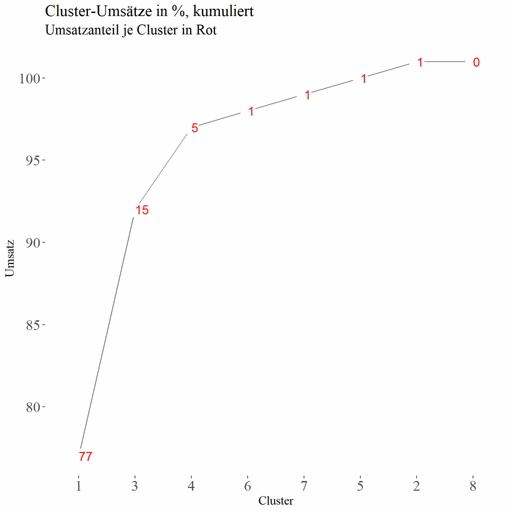

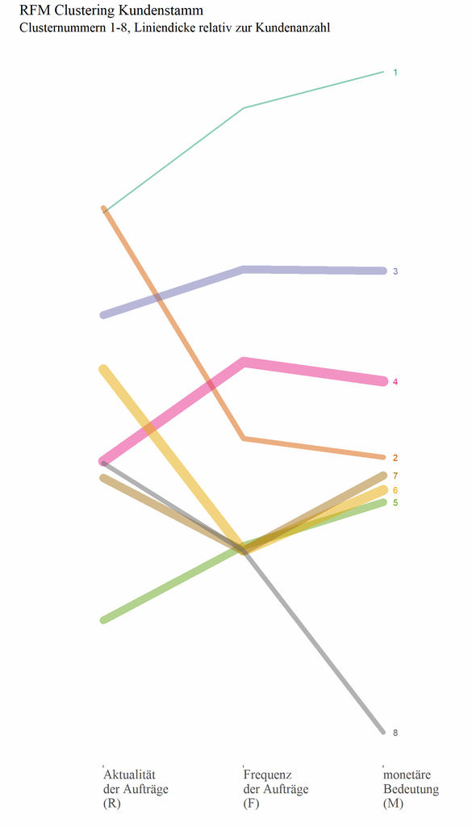

### Fazit

Die RFM Profile zeigen die Bedeutung der jeweiligen Kundencluster. Darauf basierend werden passende vertriebliche Maßnahmen ergriffen. Die Kunden in Cluster 1 sollten durch professionelles Key Account Management betreut werden. Ein Kundenverlust in diesem Cluster hat schwere finanzielle Auswirkungen. Ein Ausbau dieser Kunden ist im Umkehrschluss die einfachste Methode deutlich mehr Geld zu verdienen. Cluster 3 birgt großes Potential Kunden aufzubauen, welche perspektivisch in Cluster 1 aufrücken könnten. Neue Produkte oder neue Märkte sollten mit Hilfe dieser Kunden proaktiv angegangen werden. Cluster 2 hat eine moderate monetäre Bedeutung - aber eine extrem hohe Aktualität der Aufträge. Das RFM Profil deutet auf einen hohen Neukundenanteil hin. Diese sollten anfänglich im Prozess sehr eng begleitet werden, um ein gutes “Onboarding” zu ermöglichen und auch um das Kundenpotential besser einschätzen und abschöpfen zu können.